# Introduction to GIS in R

13/03/2018

## Outline

Goal: give an overview of the most important packages to support you with preparing and exploring data for SDM and for presenting your results

- Importing data
- Getting data
- Manipulating data
- Visualizing data

Slides at https://iobis.github.io/sdmcourse/

## Importing data

## Text delimited

```r
library(readr)

# comma separated
abra <- read_csv('data/Abra_alba_2000.csv')

# tab separated
abra <- read_delim('data/Abra_alba_2000.txt', delim = '\t')
```

## Excel: openxlsx

```r
# install.packages('openxlsx')
library(openxlsx)

# First sheet
abra <- read.xlsx('data/Abra_alba_2000.xlsx', 1)

# Sheet by name
abra <- read.xlsx('data/Abra_alba_2000.xlsx', sheet = 'Abra alba')
```

## Zipfile

```r
# Download a zip file
temp <- tempfile('nsbs', fileext = '.zip')
download.file('http://ipt.vliz.be/eurobis/archive.do?r=nsbs&v=1.1',
              temp)

# Read occurence.txt file from the zip file
data <- read_delim(unz(temp, 'occurrence.txt'), delim = '\t')
```

## Shapefile

Marine Ecoregions of the World (Spalding et al., 2007) https://www.worldwildlife.org/publications/marine-ecoregions-of-the-world-a-bioregionalization-of-coastal-and-shelf-areas

```r
library(sf)
meow <- read_sf('data/MEOW/meow_ecos.shp')

library(raster)
meow <- shapefile('data/MEOW/meow_ecos.shp')
```

## Raster

```r
library(raster)

sst <- raster('data/BO2_tempmean_ss_lonlat.tif')
sst
```

```
## class       : RasterLayer
## dimensions  : 2160, 4320, 9331200  (nrow, ncol, ncell)
## resolution  : 0.08333333, 0.08333333  (x, y)
## extent      : -180, 180, -90, 90  (xmin, xmax, ymin, ymax)
## coord. ref. : +proj=longlat +datum=WGS84 +no_defs +ellps=WGS84 +towgs84=0,0,0
## data source : /Users/samuel/a/projects/sdmcourse/session7-GIS-R/data/BO2_tempmean_ss_lonlat.tif
## names       : BO2_tempmean_ss_lonlat
## values      : -1.797733, 30.17863  (min, max)
```

## Getting data

## Environmental

```r
library(sdmpredictors)

# exploring the marine datasets
datasets <- list_datasets(terrestrial = FALSE, marine = TRUE)
View(datasets)

# exploring the layers
layers <- list_layers(datasets)
View(layers)

# download specific layers to the data directory
environment <- load_layers(c('BO2_tempmean_ss', 'BO_bathymean'),
                           datadir = 'data')
```

## Occurrences: OBIS

```r
library(robis)
ptevol <- occurrence('Pterois volitans') # red lionfish
```

```
##
Retrieved 2000 records of 2436 (82%)
Retrieved 2436 records of 2436 (100%)
```

```r
colnames(ptevol)
```

```
##  [1] "id"                            "decimalLongitude"
##  [3] "decimalLatitude"               "depth"
##  [5] "institutionCode"               "collectionCode"
##  [7] "catalogNumber"                 "individualCount"
##  [9] "datasetName"                   "phylum"
## [11] "order"                         "family"
## [13] "genus"                         "scientificName"
## [15] "originalScientificName"        "scientificNameAuthorship"
## [17] "obisID"                        "resourceID"
## [19] "species"                       "qc"
## [21] "aphiaID"                       "speciesID"
## [23] "scientificNameID"              "class"
## [25] "eventDate"                     "yearcollected"
## [27] "basisOfRecord"                 "locality"
## [29] "accessRights"                  "collectionID"
```

[output cut: 23 more lines]

## Filter by year

```r
occurrence('Pterois volitans', year = 1991,
           fields = c('id', 'decimalLongitude', 'decimalLatitude', 'year'))
```

```
##
Retrieved 11 records of 11 (100%)
```

```
##           id decimalLongitude decimalLatitude year
## 1    8317355         153.6300       -27.60000   NA
## 2   10918348          55.6000       -20.86667   NA
## 3  702259173         153.6670       -28.40000   NA
## 4  702263624         153.0330       -30.80000   NA
## 5  702428002         145.8500        -5.16667   NA
## 6  703286139         153.6330       -28.39166   NA
## 7  703690415         117.7808       -19.99333   NA
## 8  703690793         116.9650       -19.76167   NA
## 9  703690899         116.7983       -19.62833   NA
## 10 703691118         118.7017       -18.94334   NA
## 11 703691119         117.7317       -20.01917   NA
```

## Filter by date

```r
occurrence('Pterois volitans', startdate = '1980-03-01', enddate = '1980-10-30',
           fields = c('id', 'decimalLongitude', 'decimalLatitude', 'eventDate'))
```

```
##
Retrieved 3 records of 3 (100%)
```

```
##          id decimalLongitude decimalLatitude           eventDate
## 1    868932         158.1986        7.008333 1980-09-05 07:00:00
## 2 399697683        -177.8700      -29.240000 1980-08-06 10:00:00
## 3 702370348         116.0660      -20.283000 1980-05-31 10:00:00
```

## Filter by depth

```r
occurrence('Pterois volitans', startdepth = 100, enddepth = 200,
           fields = c('id', 'decimalLongitude', 'decimalLatitude', 'depth'))
```

```
##
Retrieved 10 records of 10 (100%)
```

```
##           id decimalLongitude decimalLatitude depth
## 1  703597136         127.6836      -12.391670 116.0
## 2  703597267         127.9425      -12.925975 100.0
## 3  703597268         127.9511      -12.750695 102.5
## 4  703597370         134.9856       -8.843335 107.0
## 5  703598330         113.3336      -23.551390 120.0
## 6  703690903         114.9292      -20.414165 122.5
## 7  703691121         117.5433      -19.020835 131.0
## 8  703691470         118.1525      -18.963335 119.5
## 9  703691925         117.7925      -19.168335 101.5
## 10 732957007         120.1400       13.880000 131.5
```

## Filter by polygon

With http://iobis.org/maptool) we can create a WKT for the Perhentian and Redang Islands and use this to query all occurrences.

```r
islands <- occurrence(geometry =
      paste('POLYGON ((102.68921 6.05862','102.57111 5.95346',
                      '103.07785 5.49980','103.25226 5.62555',
                      '103.07648 5.87970','102.68921 6.05862))',sep=', '))
```

```
##
Retrieved 532 records of 532 (100%)
```

## Filter by dataset

```r
datasets <- dataset(q='Adriatic-INTERREG')
```

```
##
Retrieved 6 records of 6 (100%)
```

```r
datasets$name
```

```
## [1] "Meiobenthos North Adriatic-INTERREG-FVG-Projects"
## [2] "Mesozooplankton North Adriatic-INTERREG Project"
## [3] "Microzooplankton North Adriatic-INTERREG Project"
## [4] "Microphytobenthos North Adriatic-INTERREG Project"
## [5] "Macrobenthos North Adriatic-INTERREG-FVG Project"
## [6] "Phytoplankton North Adriatic-INTERREG-FVG Project"
```

## Filter by dataset

```r
occ <- occurrence(resourceid = datasets$id, year = 1998,
           fields = c('id', 'decimalLongitude', 'decimalLatitude', 'resourceID'))
```

```
##
Retrieved 1553 records of 1553 (100%)
```

```r
head(occ)
```

```
##          id decimalLongitude decimalLatitude resourceID
## 1 719561828         13.56467        45.69350       3494
## 2 719561980         13.59617        45.66383       3494
## 3 719561996         13.56467        45.69350       3494
## 4 719561997         13.56467        45.69350       3494
## 5 719561998         13.56467        45.69350       3494
## 6 719561999         13.56467        45.69350       3494
```

## Filter by quality control

Vandepitte L., Bosch S., Tyberghein L., Waumans F., Vanhoorne B., Hernandez F., De Clerck O., & Mees J. (2015) **Fishing for data and sorting the catch: assessing the data quality, completeness and fitness for use of data in marine biogeographic databases**. Database, 2015. http://dx.doi.org/10.1093/database/bau125

```r
?qcflags
```

Categories of quality control flags:

- Data format
- Taxonomy
- Completeness
- Geography
- Depth
- Outliers

## Some filters: quality control

- 3. Taxonomy: is the taxon level genus or lower?
- 4. Geography (lat/lon): are the latitude/longitude values different from zero?
- 5. Geography (lat/lon): are the latitude/longitude values within their possible boundaries? (world coordinates)
- 7. Completeness (date/time): is the sampling year (start/end) completed and valid?

```r
qc3457 <- occurrence(resourceid = datasets$id, qc = c(3,4,5,7), year = 1998)
```

```
##
Retrieved 1005 records of 1005 (100%)
```

## Occurrences: GBIF

```r
library(rgbif)

occ_search(scientificName = 'Pterois volitans', limit = 10)
```

```
## Records found [22898]
## Records returned [10]
## No. unique hierarchies [1]
## No. media records [4]
## No. facets [0]
## Args [limit=10, offset=0, scientificName=Pterois volitans, fields=all]
## # A tibble: 10 x 81
##    name        key decimalLatitude decimalLongitude issues   datasetKey
##    <chr>     <int>           <dbl>            <dbl> <chr>    <chr>
##  1 Pteroi…  1.81e⁹         - 0.487            131   cdround… 50c9509d-22c…
##  2 Pteroi…  1.81e⁹          16.4             - 86.4 cdround… 50c9509d-22c…
##  3 Pteroi…  1.43e⁹           4.12             119   cdreps   66f6192f-6cc…
##  4 Pteroi…  1.43e⁹           4.11             119   cdreps   66f6192f-6cc…
##  5 Pteroi…  1.43e⁹           4.12             119   cdreps   66f6192f-6cc…
##  6 Pteroi…  1.43e⁹           4.24             119   cdreps   66f6192f-6cc…
##  7 Pteroi…  1.63e⁹         -16.9              146   cdround… 84a649ce-ff8…
##  8 Pteroi…  1.67e⁹         -28.0              153   gass84   50c9509d-22c…
##  9 Pteroi…  1.43e⁹           4.22             119   cdreps   66f6192f-6cc…
## 10 Pteroi…  1.43e⁹           9.51             124   cdreps   66f6192f-6cc…
## # ... with 75 more variables: publishingOrgKey <chr>,
## #   publishingCountry <chr>, protocol <chr>, lastCrawled <chr>,
## #   lastParsed <chr>, crawlId <int>, extensions <chr>,
## #   basisOfRecord <chr>, taxonKey <int>, kingdomKey <int>,
## #   phylumKey <int>, classKey <int>, orderKey <int>, familyKey <int>,
## #   genusKey <int>, speciesKey <int>, scientificName <chr>, kingdom <chr>,
## #   phylum <chr>, order <chr>, family <chr>, genus <chr>, species <chr>,
## #   genericName <chr>, specificEpithet <chr>, taxonRank <chr>,
## #   dateIdentified <chr>, coordinateUncertaintyInMeters <dbl>, year <int>,
## #   month <int>, day <int>, eventDate <chr>, modified <chr>,
## #   lastInterpreted <chr>, references <chr>, license <chr>,
## #   identifiers <chr>, facts <chr>, relations <chr>, geodeticDatum <chr>,
## #   class <chr>, countryCode <chr>, country <chr>, rightsHolder <chr>,
## #   identifier <chr>, verbatimEventDate <chr>, datasetName <chr>,
## #   verbatimLocality <chr>, gbifID <chr>, collectionCode <chr>,
## #   occurrenceID <chr>, taxonID <chr>, recordedBy <chr>,
## #   catalogNumber <chr>, http...unknown.org.occurrenceDetails <chr>,
## #   institutionCode <chr>, rights <chr>, eventTime <chr>,
## #   identificationID <chr>, elevation <dbl>, elevationAccuracy <dbl>,
## #   depth <dbl>, depthAccuracy <dbl>, waterBody <chr>, locality <chr>,
## #   type <chr>, ownerInstitutionCode <chr>, datasetID <chr>,
## #   samplingProtocol <chr>, identifiedBy <chr>, georeferenceSources <chr>,
## #   individualCount <int>, eventID <chr>, occurrenceStatus <chr>,
## #   institutionID <chr>
```

## Manipulating data

## Filtering

```r
library(dplyr)

data <- occurrence('Sargassum')
data %>% filter(scientificName == 'Sargassum muticum' & yearcollected > 2005)
```

## Reordering

```r
data %>% arrange(datasetName, desc(eventDate)) %>% print(n=10)
```

## Selecting and renaming columns

```r
data %>% select(scientificName, eventDate, lon=decimalLongitude, lat=decimalLatitude) %>% print(n=10)
```

## Unique combinations

select() can be used with distinct() to find unique combinations of values:

```r
data %>% select(scientificName, locality) %>% distinct()
```

## Adding columns

```r
data %>% tbl_df %>% mutate(zone = .bincode(minimumDepthInMeters, breaks=c(0, 20, 100))) %>%
  select(minimumDepthInMeters, zone) %>%
  filter(!is.na(zone)) %>%
  print(n = 10)
```

## Aggregation

```r
data %>% summarise(lat_mean = mean(decimalLatitude), lat_sd = sd(decimalLatitude))
data %>% group_by(scientificName) %>% summarise(records=n(), datasets=n_distinct(datasetName))
```

## Extract data from raster

```r
library(raster)
environment <- sdmpredictors::load_layers(c('BO2_tempmean_ss', 'BO_bathymean'),
                                          datadir = 'data')
abra <- robis::occurrence("Abra alba", year=2000,
                          fields = c('id', 'decimalLongitude', 'decimalLatitude', 'qc', 'depth'))
```

```
##
Retrieved 1532 records of 1532 (100%)
```

```r
extract(environment, abra[,c('decimalLongitude', 'decimalLatitude'),drop=FALSE])
```

```
##         BO2_tempmean_ss BO_bathymean
##    [1,]       17.752947          -31
##    [2,]       11.261374          -15
##    [3,]       11.319418          -34
##    [4,]       11.302471          -18
##    [5,]       11.302471          -18
##    [6,]       11.314563           -9
##    [7,]       11.254721          -23
##    [8,]       11.242078          -38
##    [9,]       11.274275          -37
##   [10,]       11.274275          -37
##   [11,]       11.251269          -36
##   [12,]       11.261044          -38
##   [13,]       11.261044          -38
##   [14,]       11.389958          -37
```

[output cut: 1518 more lines]

## Overlap with polygons

```r
library(sf)
abra_points <- st_as_sf(abra, coords = c('decimalLongitude', 'decimalLatitude'), crs = 4326)
meow <- read_sf('data/MEOW/meow_ecos.shp')

abra_meow <- st_intersection(abra_points, meow)
colnames(abra_meow)
```

```
##  [1] "id"         "qc"         "depth"      "ECO_CODE"   "ECOREGION"
##  [6] "PROV_CODE"  "PROVINCE"   "RLM_CODE"   "REALM"      "ALT_CODE"
## [11] "ECO_CODE_X" "Lat_Zone"   "geometry"
```

## Spatial thinning

```r
if (!require('devtools')) {
    install.packages('devtools', repo='http://cran.rstudio.com', dep=TRUE)
}
devtools:::install_github('mlammens/spThin')
```

## Spatial thinning

```r
library(spThin)

abra_thin <- spThin(abra, x.col = 'decimalLongitude', y.col = 'decimalLatitude',
                    dist = 10, great.circle.distance = TRUE)
NROW(abra)
```

```
## [1] 1532
```

```r
NROW(abra[abra_thin@samples[[1]],,drop=FALSE])
```

```
## [1] 480
```

## Create coastline raster

```r
coast_mask <- function(layer) {
  edges <- raster::boundaries(layer, type="inner")
  values <- getValues(edges)
  is.na(values) | values == 0
}
l <- raster('data/BO2_tempmean_ss_lonlat.tif')
mask <- coast_mask(l)
l[mask] <- NA
```

## Visualizing data

## ggplot2

http://ggplot2.tidyverse.org/reference/

All ggplot2 plots with a call to `ggplot()`, supplying default data and aesthethic mappings, specified by `aes()`. You then add layers, scales, coords and facets with `+`. To save a plot to disk, use `ggsave()`.

## Preparing data

```r
library(dplyr)
envabra <- extract(environment, abra[,c('decimalLongitude', 'decimalLatitude')])
data <- cbind(abra, envabra) %>%
  mutate(ObservationDepth = -1*depth, Bathymetry = BO_bathymean) %>%
  select(ObservationDepth, Bathymetry)
data <- data[complete.cases(data),,drop=FALSE]
data_long <- tidyr::gather(data)
```

## Points

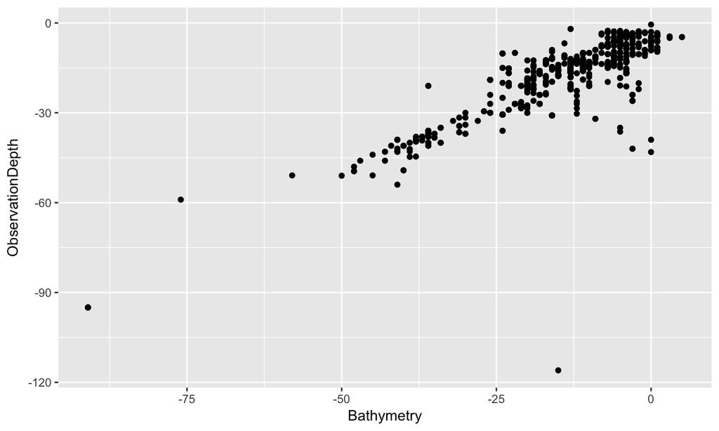

```r
library(ggplot2)
ggplot(data, aes(x=Bathymetry, y=ObservationDepth)) +
  geom_point()
```

## Boxplots

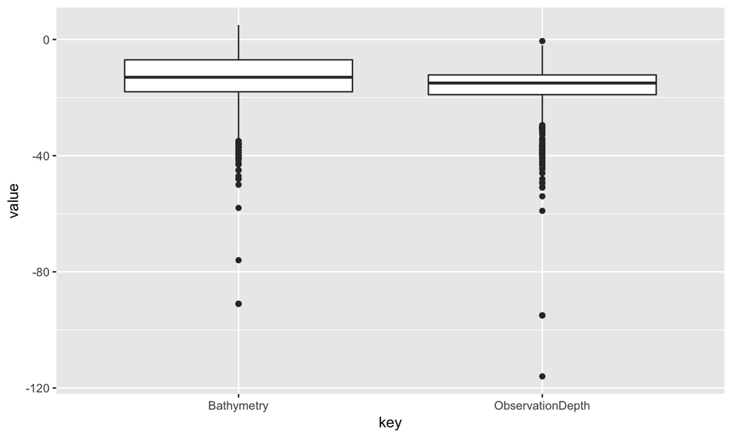

```r
ggplot(data_long, aes(x=key, y=value)) +
  geom_boxplot()
```

## Histogram

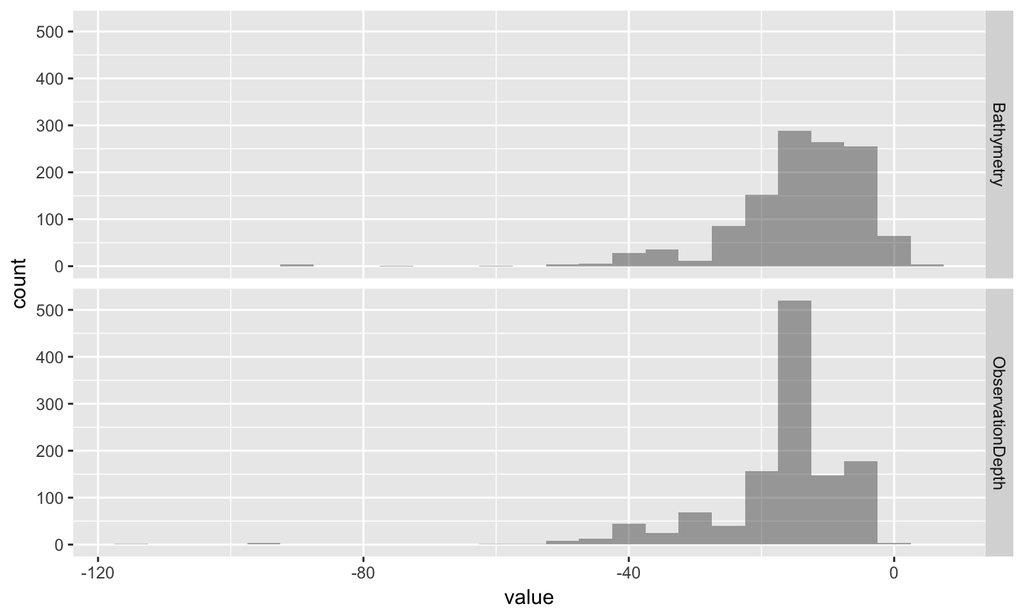

```r
ggplot(data_long, aes(x=value)) +
  geom_histogram(binwidth = 5, alpha = 0.5) +
  facet_grid(key ~ .)
```

## Frequency polygons

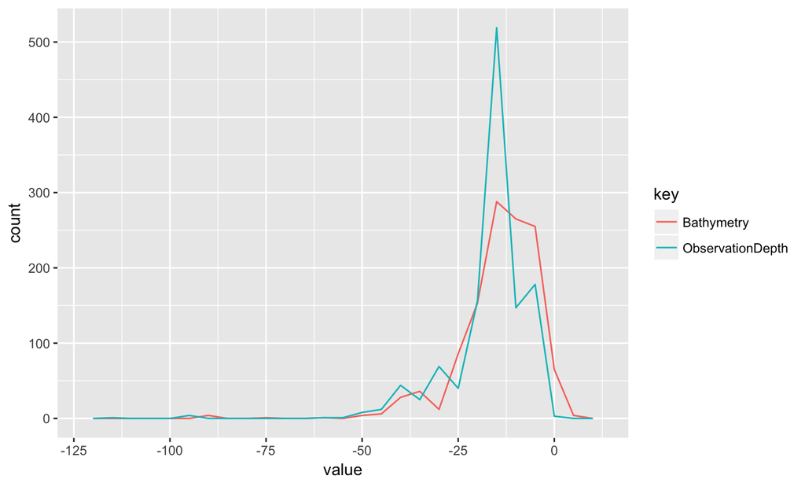

```r
ggplot(data_long, aes(x=value, colour=key)) +
  geom_freqpoly(binwidth = 5)
```

## Density

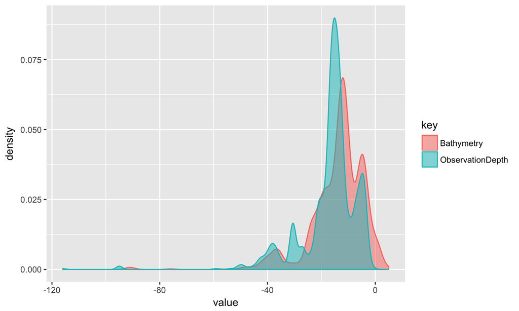

```r
ggplot(data_long, aes(x=value, fill=key, colour=key)) +
  geom_density(alpha=0.5)
```

## Correlation between rasters

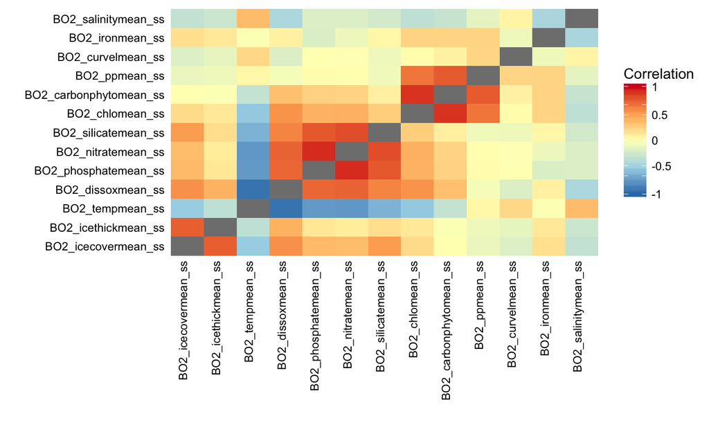

```r
library(sdmpredictors)
layers <- list_layers('Bio-ORACLE', version = 2)
meanss <- layers %>% filter(is_surface & grepl('mean[_]', layer_code))
corr <- layers_correlation(meanss$layer_code)
corr <- corr[unlist(correlation_groups(corr)), unlist(correlation_groups(corr))]
corr[corr==1] <- NA
plot_correlation(corr)
```

## Visualize QC

- 28. Species outliers (geography): is the observation within three IQRs from the first & third quartile distance to the geographic centroid of this taxon?

```r
acistu <- occurrence("Acipenser sturio") # European sea sturgeon
```

```
##
Retrieved 66 records of 66 (100%)
```

```r
acistu$qcnum <- qcflags(acistu$qc, c(28))
colors <- c("#ee3300", "#86b300")[acistu$qcnum + 1]
popup <- paste0(acistu$datasetName, "<br/>", acistu$catalogNumber,
                "<br/><a href=\"http://www.iobis.org/explore/#/dataset/",
                acistu$resourceID, "\">OBIS dataset page</a>")
```

## Visualize QC

```r
library(leaflet)
leaflet() %>% addProviderTiles("CartoDB.Positron") %>%
  addCircleMarkers(
    popup = popup, radius = 3.5, weight = 0, fillColor = colors, fillOpacity = 1,
    lat = acistu$decimalLatitude, lng = acistu$decimalLongitude)
```

[interactive chart not shown]

## Visualize QC

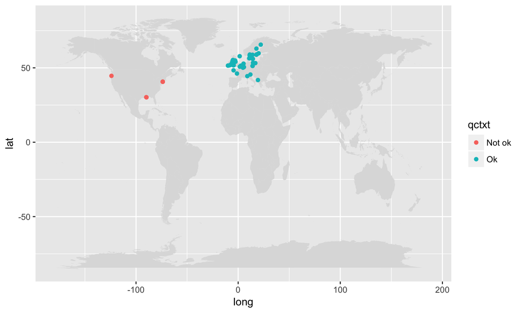

```r
acistu$qctxt <- c("Not ok", "Ok")[acistu$qcnum + 1]
ggplot() +
  geom_polygon(data=map_data("world"),aes(x=long,y=lat,group=group),fill="#dddddd")+
  geom_point(data=acistu, aes(x=decimalLongitude, y=decimalLatitude, color=qctxt))
```

## Visualize environmental data

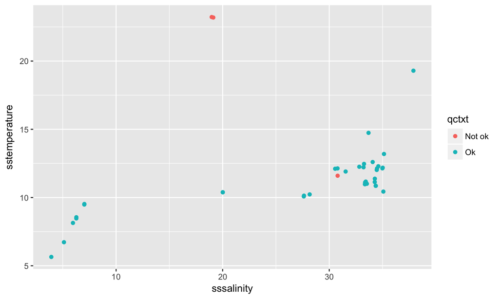

```r
# devtools::install_github('iobis/obistools')
env <- obistools::lookup_xy(acistu)
envacistu <- cbind(acistu[complete.cases(env),], env[complete.cases(env),])
ggplot(envacistu, aes(x=sssalinity, y=sstemperature, color=qctxt)) +
  geom_point()
```

## World + SST + MEOW + Abra alba

```r
meow <- read_sf('data/MEOW/meow_ecos.shp')
sst <- raster('data/BO2_tempmean_ss_lonlat.tif')
extent <- extent(-87, 25, 24, 70)
sst <- raster::crop(sst, extent)
sst_df <- as.data.frame(as(sst, "SpatialPixelsDataFrame"))
colnames(sst_df) <- c("value", "x", "y")
map <- ggplot() +
  geom_tile(data=sst_df, aes(x=x, y=y, fill=value), alpha=0.8) +
  geom_sf(data=meow, fill="darkgreen", alpha=0.1) +
  geom_polygon(data=map_data("world"),aes(x=long,y=lat,group=group),fill="#dddddd") +
  geom_point(data=abra, aes(x=decimalLongitude, y=decimalLatitude)) +
  coord_sf(xlim = c(extent@xmin+10, extent@xmax-10),
           ylim = c(extent@ymin+10, extent@ymax-10)) +
  scale_fill_distiller(palette = "Spectral") +
  labs(x="longitude", y="latitude", fill = "SST")
```

## World + SST + MEOW + Abra alba

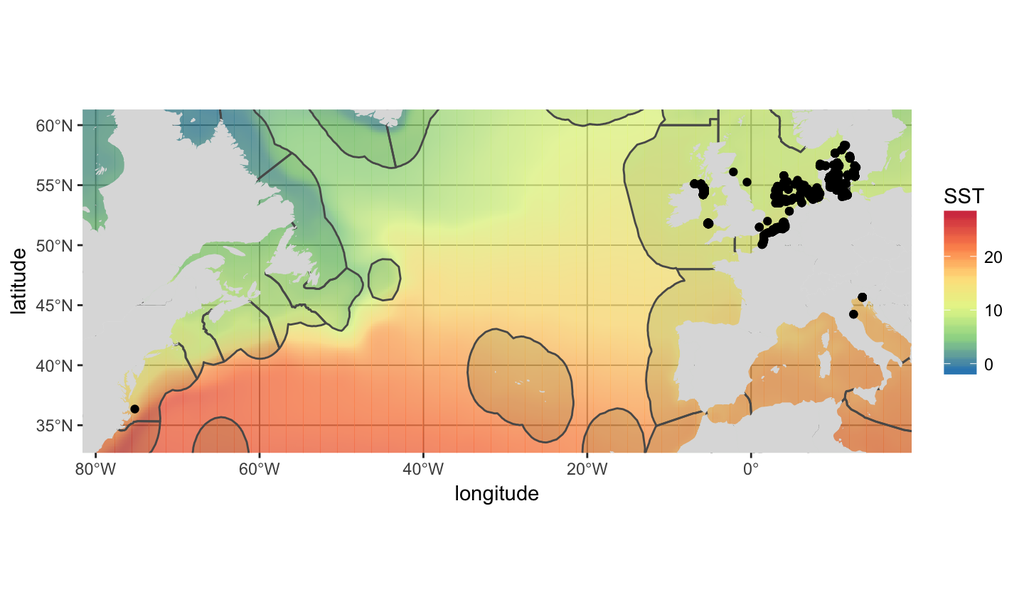

## Ten Simple Rules for Reproducible Computational Research

*Sandve GK, Nekrutenko A, Taylor J, Hovig E (2013) Ten Simple Rules for Reproducible Computational Research. PLoS Comput Biol 9(10): e1003285.* *https://doi.org/10.1371/journal.pcbi.1003285*

**Rule 1: For Every Result, Keep Track of How It Was Produced**

**Rule 2: Avoid Manual Data Manipulation Steps**

**Rule 3: Archive the Exact Versions of All External Programs Used**

**Rule 4: Version Control All Custom Scripts**

- GitHub, Bitbucket, GitLab
- https://swcarpentry.github.io/git-novice/

**Rule 5: Record All Intermediate Results, When Possible in Standardized Formats**

## Ten Simple Rules for Reproducible Computational Research

**Rule 6: For Analyses That Include Randomness, Note Underlying Random Seeds**

```
set.seed(42)
```

**Rule 7: Always Store Raw Data behind Plots**

```
write_csv
saveRDS
```

**Rule 8: Generate Hierarchical Analysis Output, Allowing Layers of Increasing Detail to Be Inspected**

**Rule 9: Connect Textual Statements to Underlying Results**

- R markdown https://rmarkdown.rstudio.com/

**Rule 10: Provide Public Access to Scripts, Runs, and Results**

## Extra

- https://www.manning.com/books/practical-data-science-with-r and their blog http://www.win-vector.com/blog/
- Books by Hadley Wickham http://hadley.nz/
- https://www.tidyverse.org/packages/
- http://marinespeed.org

## Exercises

- Plot thinned records and original records for e.g. Abra alba, zoom in on the European distribution
- Plot surface and benthic temperature against depth for Europe